# Ancestry-Stratified Rare LoF Variant Burden in Immune and Skeletal Genes

A population genomics analysis using gnomAD v4

Author

Enrique Estévez Campo

Published

July 9, 2026

## 1 Abstract

Human populations differ in their histories of migration, bottlenecks, and pathogen exposure — forces that have shaped not only observable morphological diversity but also the architecture of rare functional genetic variation. Here I present an ancestry-stratified analysis of rare loss-of-function (LoF) variant burden across 14 candidate genes spanning three biological modules: innate immunity, autoimmunity, and skeletal biology. Using gnomAD v4 exome data from 730,947 individuals across eight ancestry groups, I characterize how LoF variant burden, ancestry-specific variant density, and gene constraint vary across populations. CD36 and IFIH1 emerge as the genes with the strongest ancestry-differentiated LoF burden, consistent with hypotheses of pathogen-mediated selection previously proposed for these genes. Module B (autoimmunity) genes show consistently low burden across all ancestries, consistent with strong purifying selection. The relationship between historical effective population size and mean LoF burden shows a weak positive trend that does not reach statistical significance at this gene panel scale (R² = 0.24, p = 0.264, n = 7), highlighting the limitations of candidate gene approaches for demographic inference. This analysis bridges biological anthropology and population genomics, suggesting that the same demographic forces that diversified human morphology may leave signatures in the spectrum of rare functional variants.

**Keywords:** rare variants, loss-of-function, ancestry, gnomAD, population genomics, CD36, IFIH1, effective population size

## 2 Introduction

The observation that human populations differ in disease prevalence and drug response has long motivated the study of population-specific genetic variation. Yet the vast majority of large-scale genetic studies have focused on European-ancestry cohorts, leaving the genetic architecture of disease risk in other populations poorly characterized (Thorlacius et al. 2025). A striking illustration of this gap is the recent identification of a rare IKBKB variant — IKKβ E502K — conferring a 3-4 fold increased risk of lupus exclusively in individuals of African ancestry, a signal that would have been invisible in a European-only study (Thorlacius et al. 2025).

This project asks a related question at the population level: how does the spectrum of rare loss-of-function variation differ across human ancestry groups in genes relevant to immunity and skeletal biology? The hypothesis draws on a foundational principle of population genetics — that demographic history, specifically historical effective population size (Ne), bottlenecks, and selective pressures, shapes the distribution of rare LoF variants (Gravel et al. 2011; Lim et al. 2014). Populations with small historical Ne (e.g. Ashkenazi Jewish, Finnish) may accumulate more LoF variants through genetic drift, while populations with large Ne and ancient demographic histories (e.g. African) harbor greater allelic diversity, including potentially adaptive variants absent in other groups.

The candidate gene panel spans three biological modules with distinct evolutionary expectations. Module A (innate immunity) includes genes for which hypotheses of differential positive selection across populations have been proposed — CD36 and ACKR1 (DARC) are classical candidates for pathogen-driven adaptation, while IFIH1 has been proposed as a target of positive selection in African populations (Tenesa et al. 2007). Module B (autoimmunity) includes trans-ancestral GWAS loci for lupus and related diseases, expected to be under strong purifying selection. Module C (skeletal biology) grounds the analysis in the author’s background in biological anthropology, connecting molecular variation in osteogenesis genes to macroscopic patterns of skeletal diversity.

## 3 Methods

### 3.1 Data source

All variant data were retrieved from the gnomAD v4.0 exome dataset via the public GraphQL API (gnomAD Team 2023). gnomAD v4 contains 730,947 exome sequences mapped to GRCh38, representing the largest publicly available human exome resource. Eight ancestry groups were analyzed: African (afr), Admixed American (amr), Ashkenazi Jewish (asj), East Asian (eas), Finnish (fin), Middle Eastern (mid), Non-Finnish European (nfe), and South Asian (sas). These ancestry groups represent genetically inferred clusters rather than discrete biological populations, and their boundaries reflect both genetic structure and ascertainment decisions made during gnomAD curation. Furthermore, gnomAD is not a random population cohort — it aggregates exome and genome sequences from disease studies, biobanks, and population resources with variable ascertainment strategies, which may introduce systematic differences in variant detection power across ancestry groups.

### 3.2 Gene selection

Fifteen candidate genes were selected a priori across three biological modules based on published evidence of ancestry-specific variation, GWAS signal, or relevance to the author’s prior work in skeletal biology (Table 1). TLR10 was subsequently excluded from burden figures due to absence of LoF HC variants in gnomAD v4 exomes. Genes in Module C represent key regulatory nodes of osteogenesis rather than a single signalling pathway: RUNX2 is the master transcription factor for osteoblast differentiation, COL1A1 encodes the primary structural protein of bone matrix, SP7 acts downstream of RUNX2, LRP5 is a co-receptor in the Wnt signalling pathway regulating bone density, and VDR mediates vitamin D signalling in mineral metabolism.

```r
genes_table <- tibble(
  Module = c(rep("A: Innate immunity", 7),
             rep("B: Autoimmunity", 3),
             rep("C: Skeletal", 5)),
  Gene = c("IKBKB", "IFIH1", "TLR1", "TLR6", "TLR10",
           "ACKR1", "CD36",
           "STAT4", "IRF5", "TNFAIP3",
           "RUNX2", "COL1A1", "SP7", "LRP5", "VDR"),
  Rationale = c(
    "NF-κB kinase; lupus risk variant in Africans (Thorlacius et al. 2025)",
    "Cytosolic RNA sensor; proposed positive selection in Africans",
    "Toll-like receptor; proposed selection in non-Africans",
    "Toll-like receptor; cluster with TLR1/TLR10",
    "Toll-like receptor; no LoF HC in gnomAD v4 (excluded)",
    "Duffy antigen; classical candidate for malaria adaptation",
    "Scavenger receptor; LoF proposed protective against malaria",
    "JAK-STAT pathway; lupus GWAS in East Asians",
    "Interferon regulatory factor; trans-ancestral lupus locus",
    "NF-κB regulator; highest constraint (LOEUF=0.217)",
    "Master osteogenesis TF; FST outlier in prior work",
    "Collagen type I; essential bone matrix gene",
    "Osteoblast TF downstream of RUNX2",
    "Wnt coreceptor; bone density GWAS",
    "Vitamin D receptor; mineral metabolism and bone biology"
  )
)

kable(genes_table, booktabs = TRUE) %>%
  kable_styling(font_size = 12) %>%
  column_spec(3, width = "8cm")
```

Table 1: Candidate genes by biological module

| Module | Gene | Rationale |
| --- | --- | --- |
| A: Innate immunity | IKBKB | NF-κB kinase; lupus risk variant in Africans (Thorlacius et al. 2025) |
| A: Innate immunity | IFIH1 | Cytosolic RNA sensor; proposed positive selection in Africans |
| A: Innate immunity | TLR1 | Toll-like receptor; proposed selection in non-Africans |
| A: Innate immunity | TLR6 | Toll-like receptor; cluster with TLR1/TLR10 |
| A: Innate immunity | TLR10 | Toll-like receptor; no LoF HC in gnomAD v4 (excluded) |
| A: Innate immunity | ACKR1 | Duffy antigen; classical candidate for malaria adaptation |
| A: Innate immunity | CD36 | Scavenger receptor; LoF proposed protective against malaria |
| B: Autoimmunity | STAT4 | JAK-STAT pathway; lupus GWAS in East Asians |
| B: Autoimmunity | IRF5 | Interferon regulatory factor; trans-ancestral lupus locus |
| B: Autoimmunity | TNFAIP3 | NF-κB regulator; highest constraint (LOEUF=0.217) |
| C: Skeletal | RUNX2 | Master osteogenesis TF; FST outlier in prior work |
| C: Skeletal | COL1A1 | Collagen type I; essential bone matrix gene |
| C: Skeletal | SP7 | Osteoblast TF downstream of RUNX2 |
| C: Skeletal | LRP5 | Wnt coreceptor; bone density GWAS |
| C: Skeletal | VDR | Vitamin D receptor; mineral metabolism and bone biology |

### 3.3 Variant filtering

Variants were filtered through three sequential steps:

1. **Data type**: exomes only, per-ancestry rows, excluding `ALL` and `remaining` categories
2. **Rarity**: allele frequency < 1% per ancestry (applied per-ancestry intentionally, to capture variants rare within each specific population)
3. **Functionality**: high-confidence loss-of-function variants only, as annotated by LOFTEE (Loss-Of-Function Transcript Effect Estimator) with the HC (high-confidence) flag. LOFTEE applies a series of stringent filters beyond simple variant consequence annotation: it removes variants in the last 5% of the transcript (where LoF may not result in nonsense-mediated decay), filters splice-site variants that do not disrupt the canonical splice dinucleotides, excludes variants in low-complexity or poorly mappable regions, and flags variants where the LoF annotation may be a sequencing or alignment artefact. Only variants passing all LOFTEE HC criteria were retained. Missense variants were excluded from the primary analysis because, without CADD pathogenicity filtering, they inflate burden with likely benign variants (Pearson r = 0.46 between missense+LoF and LoF-only burden in an internal sensitivity analysis).

### 3.4 Burden calculation

LoF burden per gene per ancestry was calculated as:

$$\text{Burden} = \frac{\sum AC}{\max(AN)} \times 10{,}000$$

where $\sum AC$ is the total allele count of all rare LoF HC variants, and $\max(AN)$ is the maximum allele number observed across variants in that gene × ancestry combination. max(AN) approximates the total callable chromosomes, avoiding downward bias from low-coverage variants that would inflate burden if mean(AN) were used instead.

For the demographic scatter analysis, ancestry groups with mean AN < 10,000 were excluded to avoid spurious burden estimates from underpowered populations (Middle Eastern excluded).

### 3.5 Constraint metrics

LOEUF (upper bound of the observed/expected LoF ratio confidence interval) and pLI were retrieved for each gene via the gnomAD GraphQL API. LOEUF thresholds follow Karczewski et al. 2020 (Karczewski et al. 2020): < 0.35 highly constrained, 0.35–0.70 moderately constrained, > 0.70 tolerant.

### 3.6 Historical effective population size

Historical Ne estimates were obtained from published demographic inference studies: Tenesa et al. (2007) for African, East Asian, and Non-Finnish European populations; Gravel et al. (2011) for Admixed American and South Asian; Carmi et al. (2014) for Ashkenazi Jewish; and Lim et al. (2014) for Finnish. These values are model-dependent approximations and should be interpreted as order-of-magnitude estimates rather than precise quantities.

## 4 Results

### 4.1 Variant counts

```r
df <- fread(
  "/Users/kike/projects/rare-variant-ancestry-burden/data/raw/all_genes_gnomad_v4.tsv",
  colClasses = list(character = c("lof", "lof_filter", "consequence"))
)

df_clean <- df %>%
  filter(data_type == "exome", ancestry != "ALL",
         ancestry != "remaining", an > 0)

df_rare <- df_clean %>% filter(af < 0.01)

df_lof_only <- df_rare %>% filter(lof == "HC")
```

After filtering, 29,112 variant × ancestry rows remained, representing 1823 unique LoF HC variants across 14 genes (TLR10 excluded). CD36 harbored the most LoF HC variants (n = 409), followed by IFIH1 (296) and LRP5 (272). ACKR1 had the fewest (n = 4), consistent with its high LOEUF (3.06) indicating tolerance to LoF variation.

### 4.2 LoF burden across ancestries

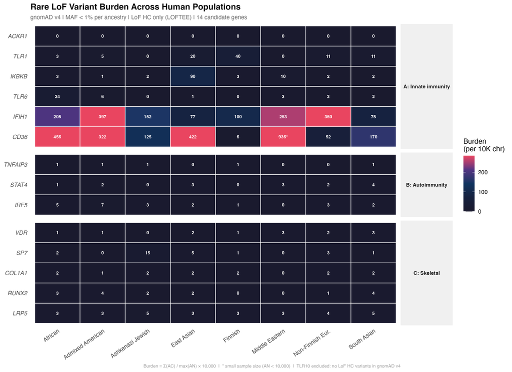

Figure 1: Rare LoF variant burden across 14 candidate genes and 8 ancestry groups. Burden = Σ(AC)/max(AN) × 10,000. Middle Eastern values flagged with * indicate small sample size (AN < 10,000). TLR10 excluded: no LoF HC variants in gnomAD v4.

```r
knitr::include_graphics("/Users/kike/projects/rare-variant-ancestry-burden/figures/01_burden_heatmap.png")
```

Within this candidate panel, CD36 and IFIH1 show the strongest ancestry-differentiated LoF burden (Figure 1). CD36 burden in African individuals (456 per 10K chromosomes) and East Asian (422) substantially exceeds Finnish (6) and Non-Finnish European (52), a pattern consistent with hypotheses of pathogen-mediated selection previously proposed for CD36. IFIH1, encoding the cytosolic RNA sensor MDA5, shows elevated burden across Admixed American (397), Middle Eastern (253), and Non-Finnish European (350) populations.

In contrast, Module B (autoimmunity) genes — STAT4, IRF5, and TNFAIP3 — show consistently low LoF burden across all ancestries (values < 10 per 10K chromosomes in most cases), consistent with strong purifying selection. Module C (skeletal) genes likewise show low burden within this panel, with COL1A1 and RUNX2 near zero across all populations.

### 4.3 Ancestry-specific LoF variants

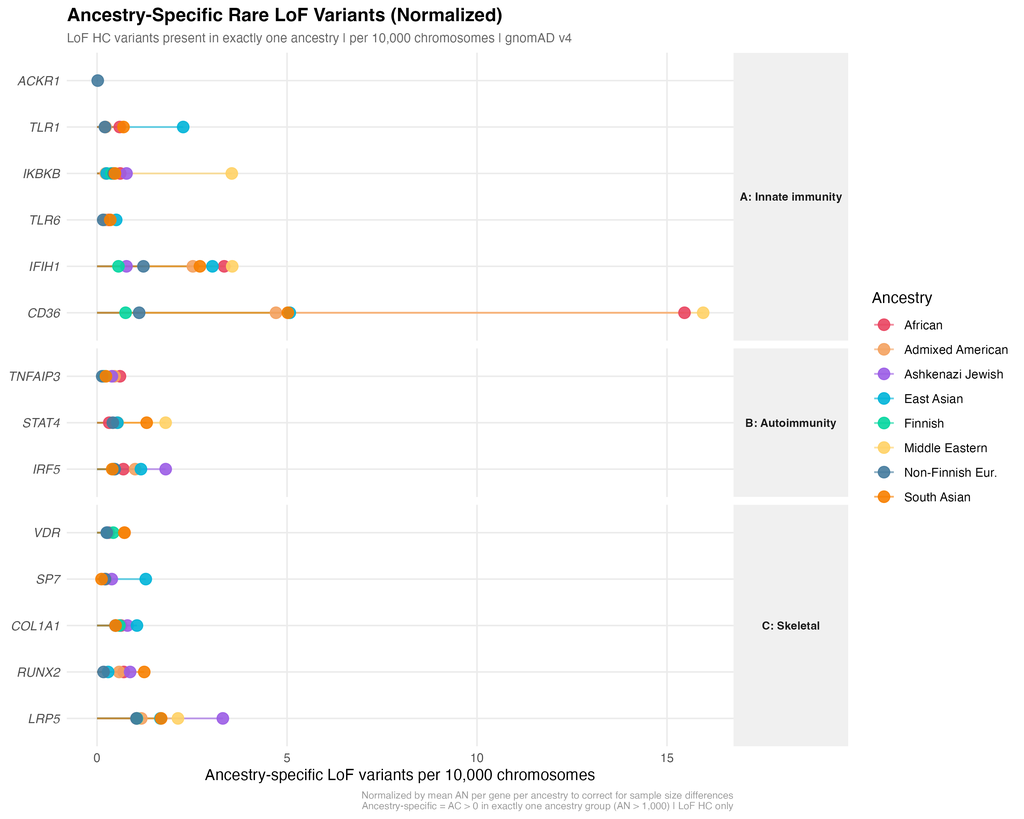

Figure 2: Normalized density of ancestry-specific rare LoF variants per gene. Ancestry-specific defined as AC > 0 in exactly one ancestry group (AN > 1,000). Normalized by mean AN per gene per ancestry to correct for sample size differences.

```r
knitr::include_graphics("/Users/kike/projects/rare-variant-ancestry-burden/figures/02_ancestry_specific_lollipop.png")
```

CD36 shows the highest density of ancestry-specific LoF variants in both African (15.5 per 10K chromosomes) and Middle Eastern (16.0) populations (Figure 2). IFIH1 shows consistent enrichment of ancestry-specific variants across multiple non-European groups within this candidate panel. Most Module C genes show near-zero ancestry-specific LoF variant density, consistent with strong purifying selection.

### 4.4 Demographic context

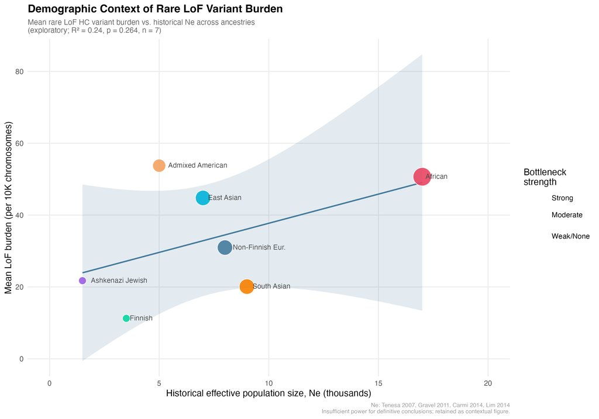

Figure 3: Mean LoF burden vs. historical Ne estimates across ancestry groups. Exploratory analysis: R² = 0.24, p = 0.264, n = 7. Middle Eastern excluded (AN < 10,000). Point size reflects bottleneck strength.

```r
knitr::include_graphics("/Users/kike/projects/rare-variant-ancestry-burden/figures/03_demographic_burden_scatter.png")
```

### 4.5 Gene constraint

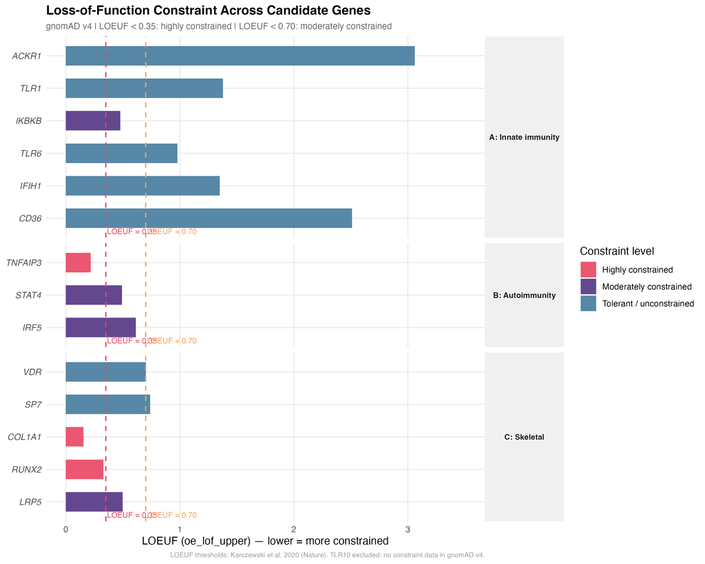

Figure 4: LOEUF scores across candidate genes. Lower values indicate stronger intolerance to LoF variation. Dashed lines mark thresholds from Karczewski et al. 2020.

```r
knitr::include_graphics("/Users/kike/projects/rare-variant-ancestry-burden/figures/04_constraint_loeuf.png")
```

## 5 Discussion

### 5.1 *CD36* and pathogen-driven adaptation

The strongest signal within this candidate panel is the ancestry-differentiated LoF burden of *CD36*, which encodes a scavenger receptor involved in the cytoadherence of *Plasmodium falciparum*-infected erythrocytes. CD36 LoF burden is substantially higher in African and East Asian populations than in European or South Asian groups, a pattern consistent with hypotheses of pathogen-mediated selection previously proposed for this gene. However, the present analysis cannot distinguish between positive selection, genetic drift, founder effects, or differences in mutational target size as explanations for this pattern. Functional validation and population genetic tests of selection would be required to support causal interpretation.

It should also be noted that for *ACKR1*, the classical malaria adaptation hypothesis primarily concerns the Duffy-null allele at the promoter level rather than LoF HC variants specifically. The near-zero LoF HC burden observed for *ACKR1* in this analysis is consistent with its high LOEUF (3.06) but does not directly speak to the Duffy-null selection hypothesis.

### 5.3 Constraint as an explanatory framework

Within this candidate panel, gene constraint (LOEUF) is broadly consistent with the observed burden patterns — tolerant genes accumulate more ancestry-specific LoF variation, while constrained genes show near-zero burden regardless of ancestry. This is consistent with purifying selection limiting the accumulation of LoF variants in essential genes, potentially outweighing demographic effects. However, LOEUF is itself derived from observed LoF depletion in gnomAD, which introduces circularity when used to explain LoF burden patterns in the same dataset. Additional factors including gene length, local mutation rate, CpG density, and sequencing coverage also contribute to burden differences and are not accounted for in this analysis.

### 5.4 The founder effect: from Iceland to global genome architecture

The logic underlying this entire analysis is perhaps best illustrated by a single population: Iceland. Settled in the 9th century by a founding group estimated at fewer than 10,000 individuals — predominantly Norse and Celtic — Iceland underwent one of the most extreme demographic bottlenecks in recent human history (Karczewski et al. 2020). The mathematical consequence is well understood: when Ne drops sharply, genetic drift overpowers purifying selection for variants of moderate effect, allowing mildly deleterious LoF alleles to reach frequencies far above what would be expected in a large outbred population (Lim et al. 2014). Over 35 generations of relative isolation, this process produced a population where rare variants are enriched, linkage disequilibrium extends over longer genomic distances, and haplotype sharing is pervasive — properties that make isolated founder populations exceptional resources for discovering variant-disease associations that would be statistically invisible in more diverse cohorts.

This demographic logic has profound implications for disease gene discovery. In isolated founder populations, variants that drifted to detectable frequencies during the bottleneck can be linked to phenotypes with statistical power unavailable in large outbred cohorts — because the same haplotype background is shared across thousands of distantly related individuals, effectively providing a natural controlled experiment. The IKBKB E502K variant identified in African-ancestry lupus cohorts (Thorlacius et al. 2025) illustrates the complementary insight from the opposite direction: that ancestry-specific rare variants of large effect exist in every human population, but can only be detected when that population is studied with sufficient depth and without the assumption that European reference panels are universal. Taken together, these examples suggest that the most powerful strategy for rare variant discovery is not to treat ancestry as a confound to be corrected away, but as a primary axis of analysis — and demographic history not as noise, but as signal.

### 5.5 Connection to biological anthropology

This candidate panel analysis provides preliminary support for the hypothesis that the demographic forces shaping observable human morphological diversity also leave signatures in the spectrum of rare LoF variants — at least for genes under proposed pathogen-mediated selection. For highly constrained genes (COL1A1, RUNX2), purifying selection appears to limit LoF burden consistently across all populations, potentially outweighing demographic differences. The weak and non-significant demographic scatter suggests that a genome-wide approach, rather than a candidate gene panel, would be necessary to formally test this hypothesis.

### 5.6 Limitations

Several limitations should be noted. First, genes were selected a priori based on prior hypotheses, introducing ascertainment bias. Conclusions about demographic patterns should therefore be interpreted within this candidate panel and not generalized to the human genome. Second, missense variants were excluded without CADD filtering, potentially missing pathogenic missense variation. Third, Middle Eastern ancestry was excluded from the demographic analysis due to small sample size in gnomAD v4 (AN < 10,000 for most genes). Fourth, the burden metric (ΣAC/max(AN)) is an approximation that does not account for gene length, local mutation rate, or the specific functional impact of individual variants. Fifth, gnomAD is not a random population cohort — it aggregates samples from disease studies and biobanks with variable ascertainment, which may introduce systematic biases in variant detection power across ancestry groups. Sixth, the ancestry groups used here are genetically inferred clusters rather than discrete biological populations, and their composition reflects both genetic structure and ascertainment decisions in gnomAD curation. Seventh, this analysis uses population-level summary statistics from gnomAD and therefore cannot control for cryptic relatedness or fine-scale population structure within ancestry groups. Access to individual-level genotype data, as available in biobanks such as UK Biobank or All of Us, would enable principal component analysis and kinship-based corrections that are standard in association studies but not feasible here.

## 6 Conclusions

Within this candidate gene panel, ancestry-stratified rare LoF variant burden varies substantially across immune genes, particularly *CD36* and *IFIH1*, in patterns consistent with hypotheses of pathogen-mediated selection previously proposed for these genes. Module B (autoimmunity) and Module C (skeletal) genes show consistently low LoF burden consistent with strong purifying selection. The relationship between historical Ne estimates and mean LoF burden is positive but does not reach statistical significance at this gene panel scale. Future work should extend this approach to genome-wide data, incorporate CADD-filtered missense variants, and apply formal population genetic tests of selection to move from descriptive burden analysis to causal inference.

## 7 References

Carmi, Shai, Ken Y Hui, Ethan Kochav, et al. 2014. “Sequencing an Ashkenazi Reference Panel Supports Population-Targeted Personal Genomics and Illuminates Jewish and European Origins.” *Nature Communications* 5: 4835. https://doi.org/10.1038/ncomms5835.

gnomAD Team. 2023. *GnomAD V4.0 Release: 730,947 Exomes and 76,215 Genomes Mapped to GRCh38*. https://gnomad.broadinstitute.org/news/2023-11-gnomad-v4-0/.

Gravel, Simon, Brenna M Henn, Ryan N Gutenkunst, et al. 2011. “Demographic History and Rare Allele Sharing Among Human Populations.” *Proceedings of the National Academy of Sciences* 108: 11983–88. https://doi.org/10.1073/pnas.1019276108.

Karczewski, Konrad J et al. 2020. “The Mutational Constraint Spectrum Quantified from Variation in 141,456 Humans.” *Nature* 581: 434–43. https://doi.org/10.1038/s41586-020-2308-7.

Lim, Elaine T, Peter Würtz, Aki S Havulinna, et al. 2014. “Distribution and Medical Impact of Loss-of-Function Variants in the Finnish Founder Population.” *PLOS Genetics* 10: e1004494. https://doi.org/10.1371/journal.pgen.1004494.

Tenesa, Albert, Pau Navarro, Ben J Hayes, et al. 2007. “Recent Human Effective Population Size Estimated from Linkage Disequilibrium.” *Genome Research* 17: 520–26. https://doi.org/10.1101/gr.6023607.

Thorlacius, Gudny Ella et al. 2025. “African-Ancestry-Specific Variant IKKβ p.Glu502Lys Confers High Lupus Risk.” *Nature Genetics* 57: 2980–86. https://doi.org/10.1038/s41588-025-02398-6.